## Graphics with R

To test plot functions, we’ll use the iris data.set

```r
head(iris)
```

```
  Sepal.Length Sepal.Width Petal.Length Petal.Width Species
1          5.1         3.5          1.4         0.2  setosa
2          4.9         3.0          1.4         0.2  setosa
3          4.7         3.2          1.3         0.2  setosa
4          4.6         3.1          1.5         0.2  setosa
5          5.0         3.6          1.4         0.2  setosa
6          5.4         3.9          1.7         0.4  setosa
```

# Basic plots

## Scatter plots

The simplest plots in R are scatter plots. A scatter plot pairs up values of two quantitative variables in a data set and display them as geometric points inside a Cartesian diagram. They are obtained by using the function `plot(x,y)`.

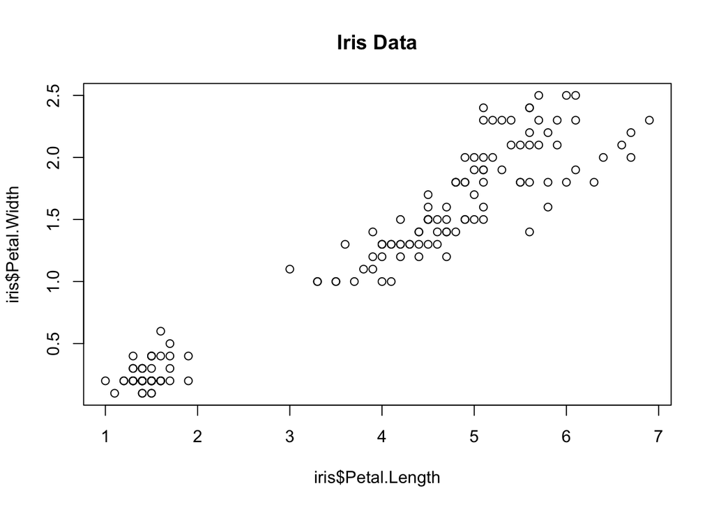

```r
plot(iris$Petal.Length, iris$Petal.Width, main="Iris Data")
```

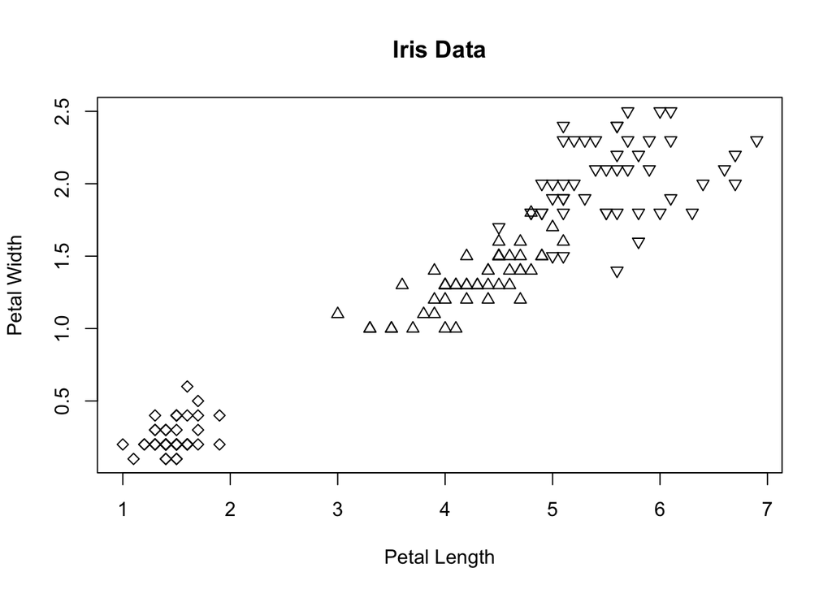

```r
plot(iris$Petal.Length, iris$Petal.Width, pch=c(23,24,25)[unclass(iris$Species)], main="Iris Data", xlab="Petal Length", ylab="Petal Width")
```

We can also add colors and a legend

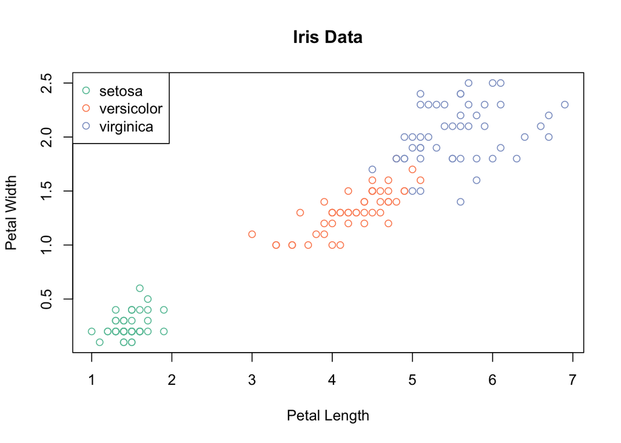

```r
library(RColorBrewer)
plot(iris$Petal.Length, iris$Petal.Width, pch=21, col=brewer.pal(3, "Set2")[iris$Species], main="Iris Data", xlab="Petal Length", ylab="Petal Width")
legend("topleft", legend=levels(iris$Species), col=brewer.pal(3, "Set2"), pch=1)
```

## Box-plots

Boxplots are useful to represent simple variables. The box plot (a.k.a. box and whisker diagram) is a standardized way of displaying the distribution of data based on the five number summary: minimum, first quartile, median, third quartile, and maximum.

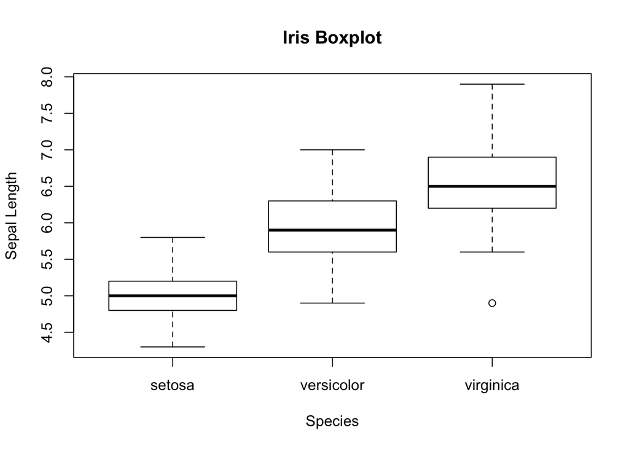

```r
boxplot(Sepal.Length~Species,data=iris,
        xlab="Species", ylab="Sepal Length", main="Iris Boxplot")
```

For example a bar plot of the Iris Species can be obtained as follows:

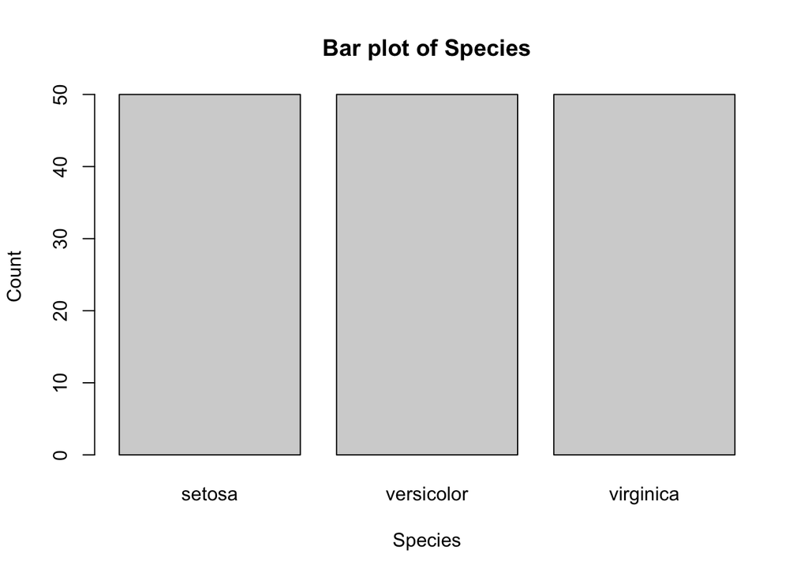

```r
barplot(table(iris$Species), col="lightgrey", xlab="Species", ylab="Count", main="Bar plot of Species")
```

As the iris contains 50 samples of each species, lets create a sub-dataset to get a smoother histogram

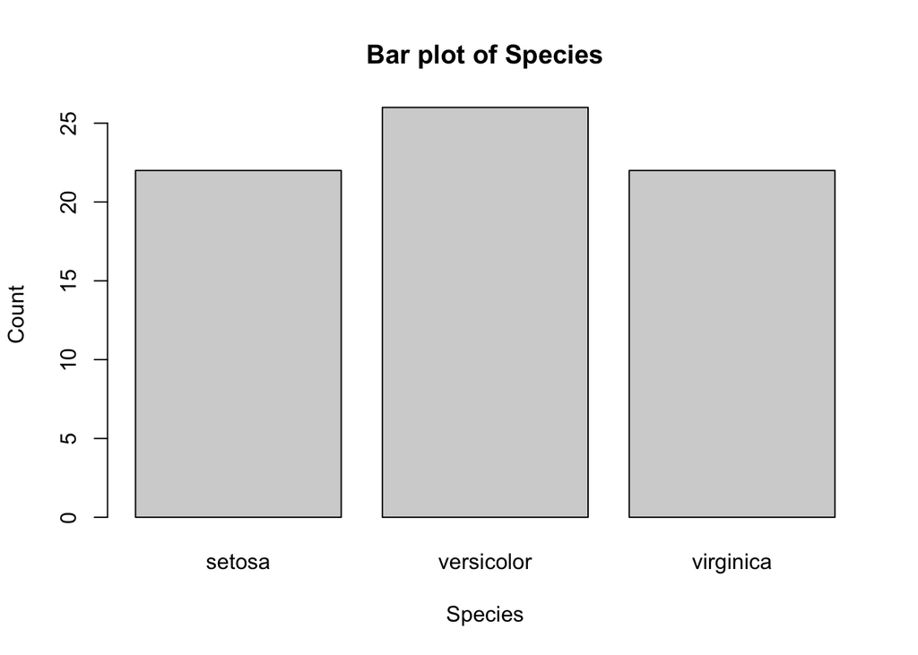

```r
iris1 <- iris[sample(1:nrow(iris), 70), ]
barplot(table(iris1$Species), col="lightgrey", xlab="Species", ylab="Count", main="Bar plot of Species")
```

## Histograms

Histograms are widely use in statistics to visually estimate the stastistical distribution of variables. A histogram is a diagram consisting of rectangles whose area is proportional to the frequency of a variable and whose width is equal to the class interval.

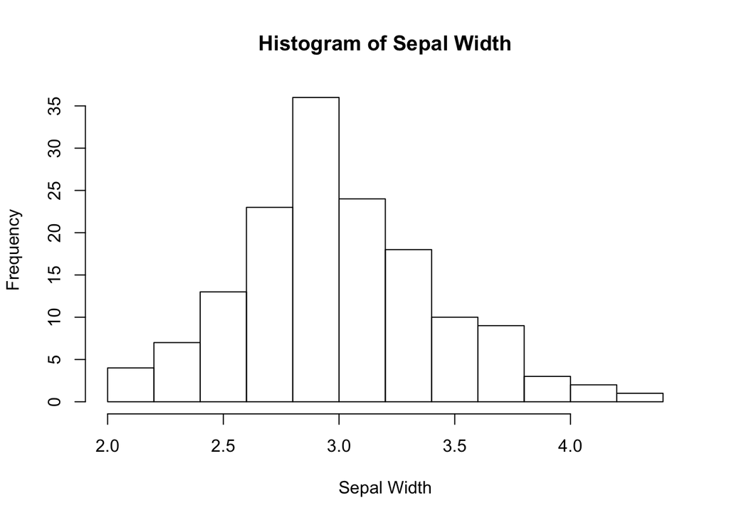

```r
hist(iris$Sepal.Width, freq=NULL, density=NULL, breaks=12,
     xlab="Sepal Width", ylab="Frequency", main="Histogram of Sepal Width")
```

It is also possible to add the density curve:

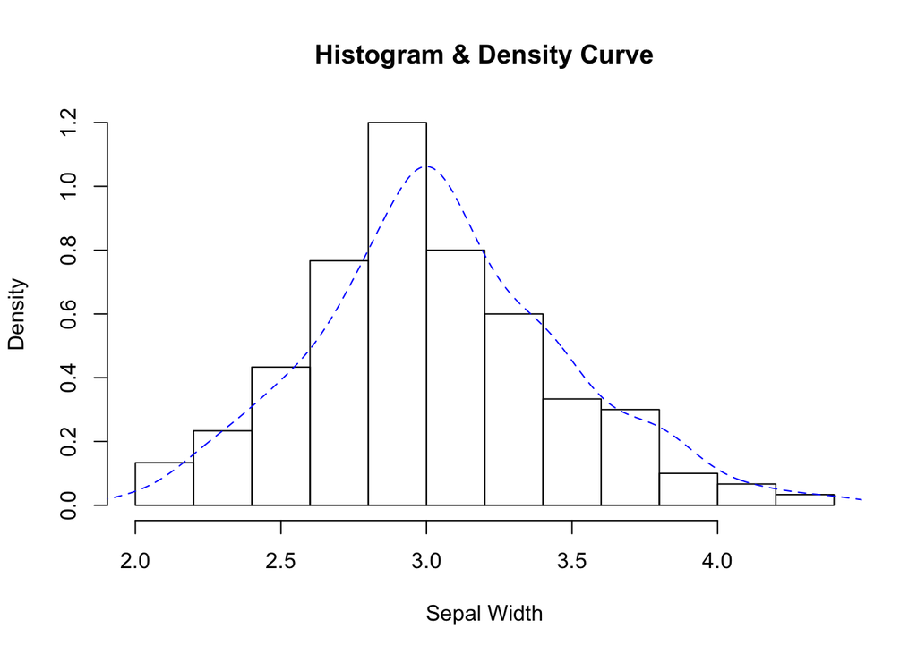

```r
 d <- density(iris$Sepal.Width)
hist(iris$Sepal.Width, breaks=12, prob=TRUE, xlab="Sepal Width", main="Histogram & Density Curve")
lines(d, lty=2, col="blue")
```

# Advanced plots with ggplot2

ggplot2 is a plotting system for R, based on the grammar of graphics, which tries to take the good parts of base and lattice graphics and none of the bad parts. It takes care of many of the fiddly details that make plotting a hassle (like drawing legends) as well as providing a powerful model of graphics that makes it easy to produce complex multi-layered graphics.

## Scatter plot

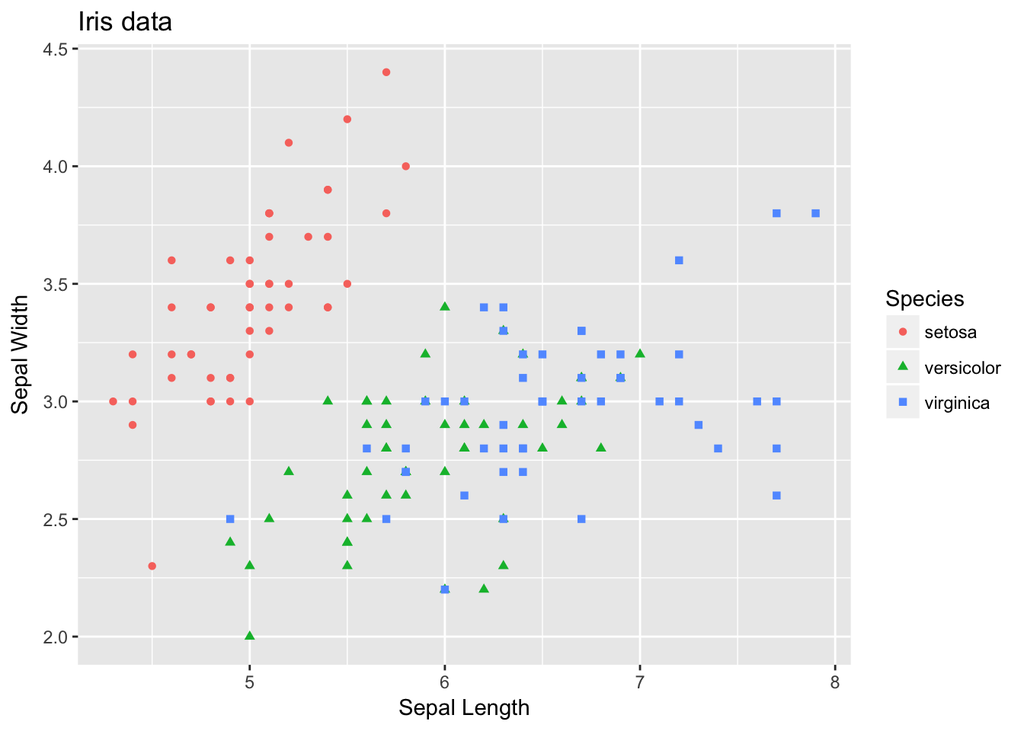

```r
library(ggplot2)
scatter <- ggplot(data=iris, aes(x = Sepal.Length, y = Sepal.Width))
scatter + geom_point(aes(color=Species, shape=Species)) +
  xlab("Sepal Length") +  ylab("Sepal Width") +
  ggtitle("Iris data")
```

Another way of doing thta is using grdaient colors (temperature-like)

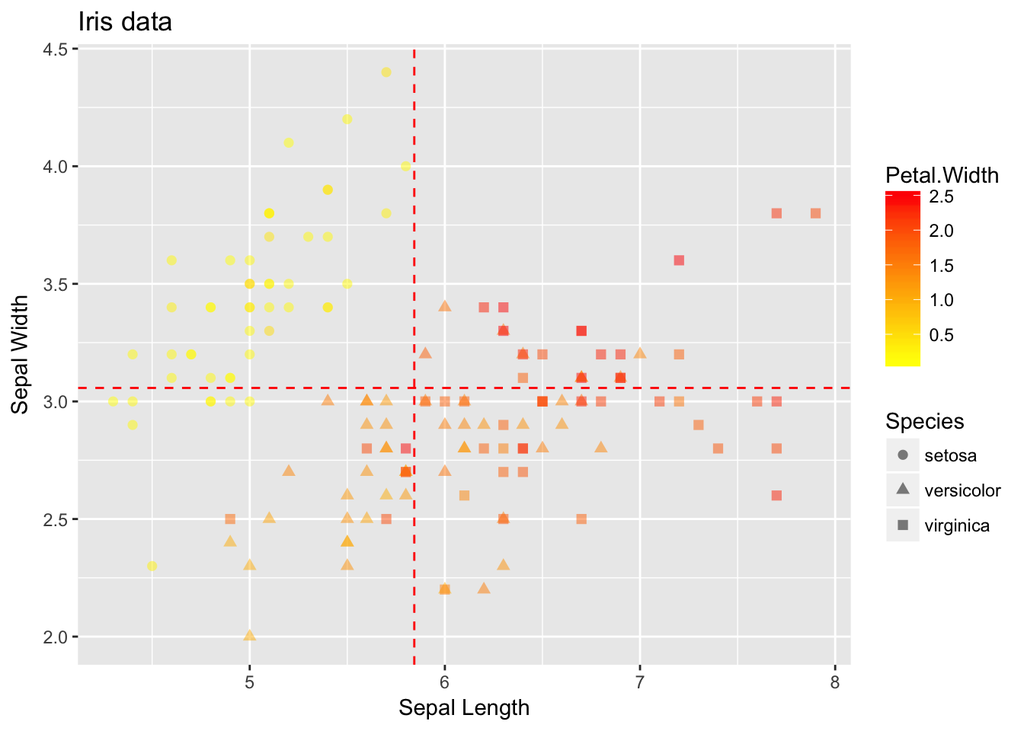

```r
scatter + geom_point(aes(color = Petal.Width, shape = Species), size = 2, alpha = I(1/2)) +
          geom_vline(aes(xintercept = mean(Sepal.Length)), color = "red", linetype = "dashed") +
          geom_hline(aes(yintercept = mean(Sepal.Width)), color = "red", linetype = "dashed") +
          scale_color_gradient(low = "yellow", high = "red") +
          xlab("Sepal Length") +  ylab("Sepal Width") +
          ggtitle("Iris data")
```

ggplot2 allows adding smoothers to the scatterplot

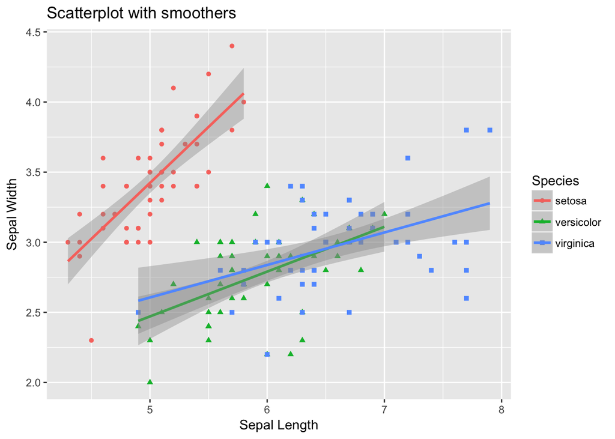

```r
smooth <- ggplot(data=iris, aes(x=Sepal.Length, y=Sepal.Width, color=Species)) +
  geom_point(aes(shape=Species), size=1.5) + xlab("Sepal Length") + ylab("Sepal Width") +
  ggtitle("Scatterplot with smoothers")

# Linear model
smooth + geom_smooth(method="lm")
```

[figure not shown]

```r
# Local polynomial regression
smooth + geom_smooth(method="loess")
```

[figure not shown]

```r
# generalised additive model
smooth + geom_smooth(method="gam", formula= y~s(x, bs="cs"))
```

## Boxplot

With ggplot2, boxplots can be obtained as follows:

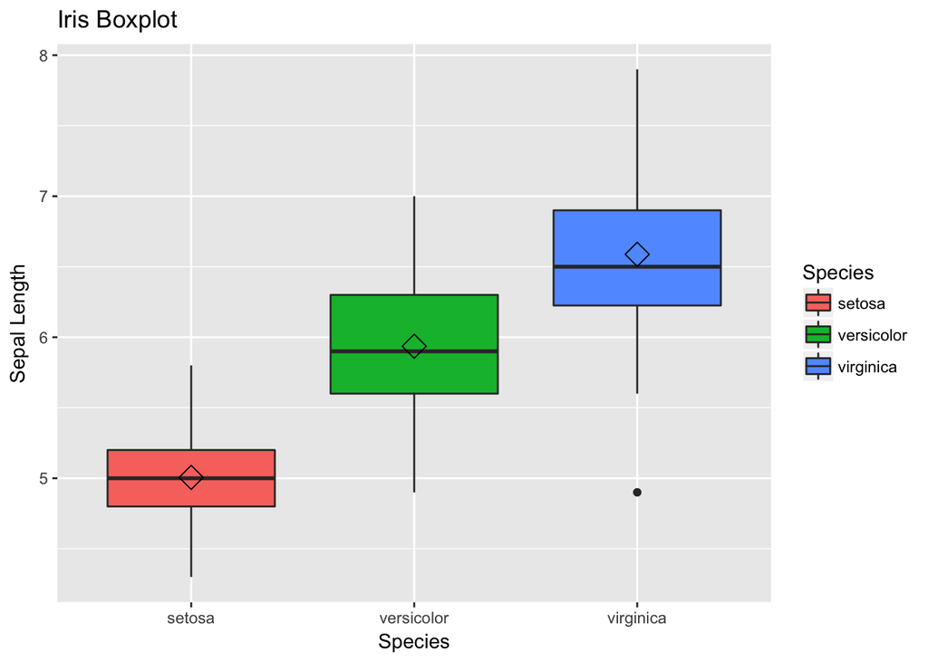

```r
box <- ggplot(data=iris, aes(x=Species, y=Sepal.Length))
box + geom_boxplot(aes(fill=Species)) +
  ylab("Sepal Length") + ggtitle("Iris Boxplot") +
  stat_summary(fun.y=mean, geom="point", shape=5, size=4)
```

## Bar plot

A bar-plot with ggplot2:

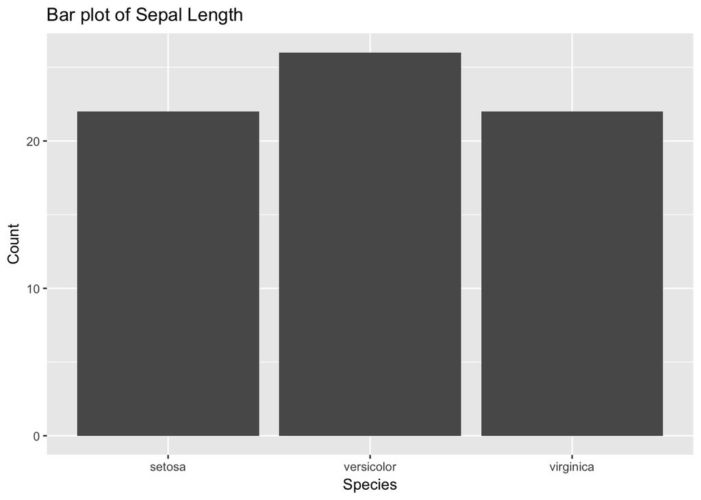

```r
bar <- ggplot(data=iris1, aes(x=Species))
bar + geom_bar() +
  xlab("Species") +  ylab("Count") + ggtitle("Bar plot of Sepal Length")
```

Advanced bar plots can be obtained by melting hte data as follows:

```r
library(reshape2)
iris2 <- melt(iris, id.vars="Species")
head(iris2)
```

```
  Species     variable value
1  setosa Sepal.Length   5.1
2  setosa Sepal.Length   4.9
3  setosa Sepal.Length   4.7
4  setosa Sepal.Length   4.6
5  setosa Sepal.Length   5.0
6  setosa Sepal.Length   5.4
```

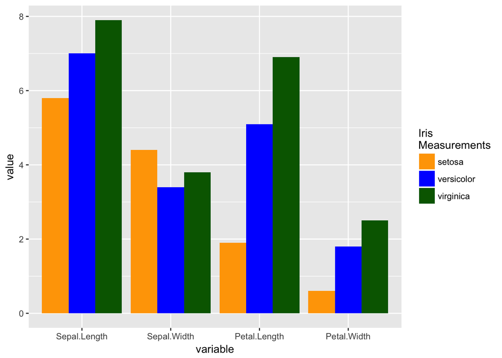

```r
bar1 <- ggplot(data=iris2, aes(x=variable, y=value, fill=Species))
bar1 + geom_bar(stat="identity", position="dodge") +
  scale_fill_manual(values=c("orange", "blue", "darkgreen", "purple"),
                    name="Iris\nMeasurements",
                    breaks=unique(iris2$Species),
                    labels=unique(iris2$Species))
```

## Histograms

Histograms can also be obtained with ggplot2:

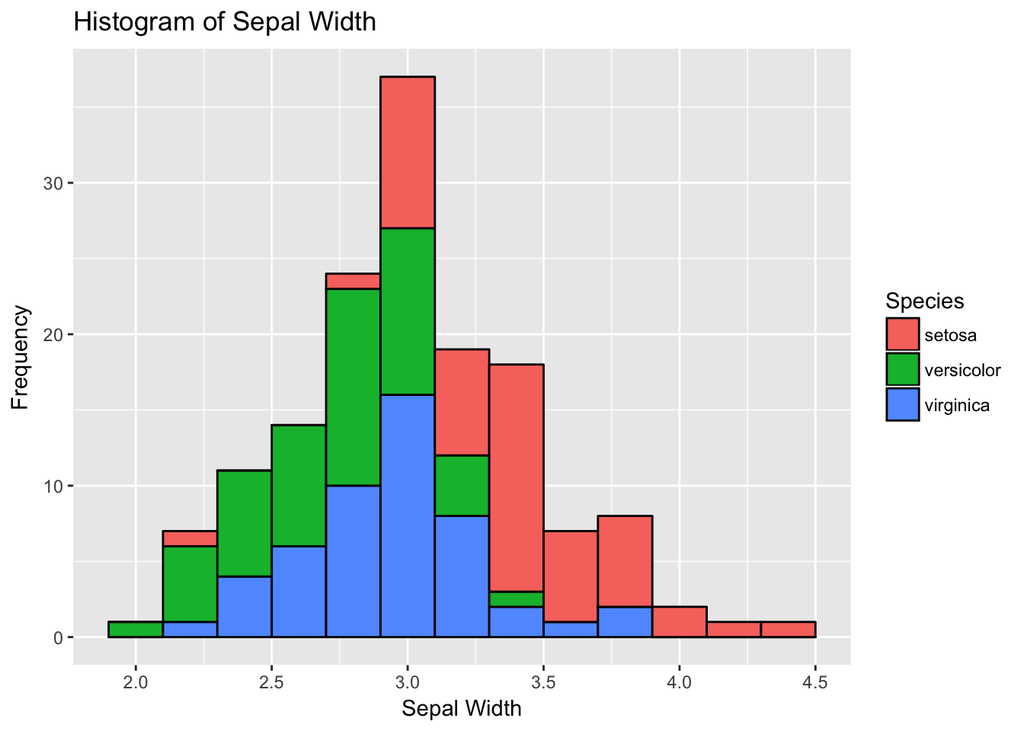

```r
library(ggplot2)
histogram <- ggplot(data=iris, aes(x=Sepal.Width))
histogram + geom_histogram(binwidth=0.2, color="black", aes(fill=Species)) +
  xlab("Sepal Width") +  ylab("Frequency") + ggtitle("Histogram of Sepal Width")
```

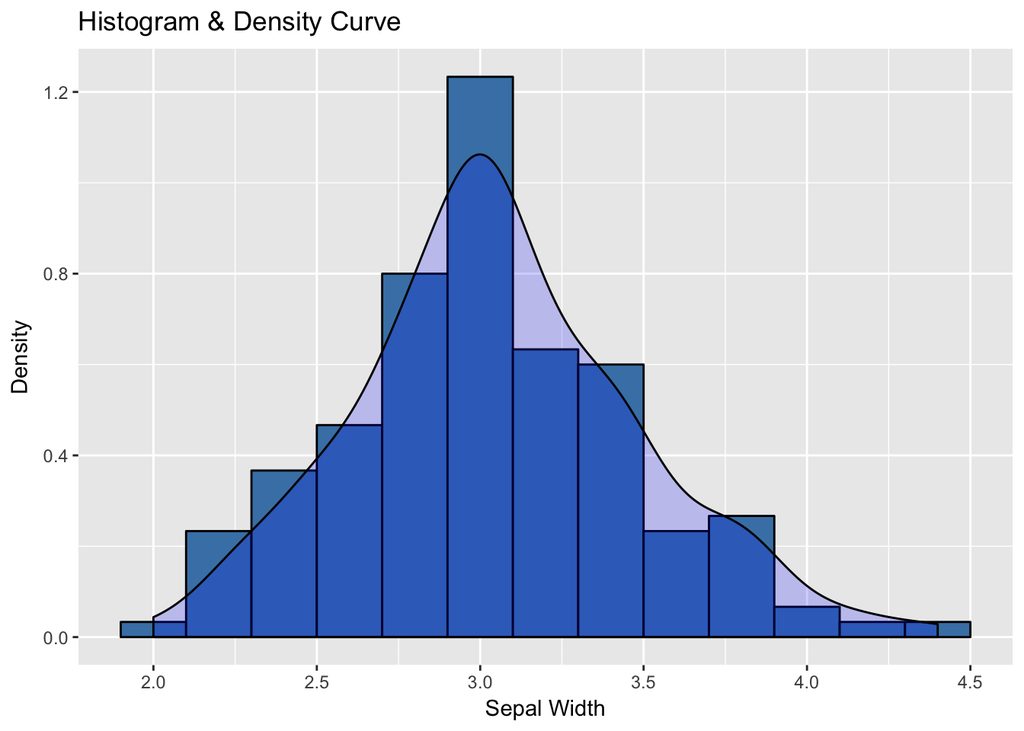

```r
density <- ggplot(data=iris, aes(x=Sepal.Width))
density + geom_histogram(binwidth=0.2, color="black", fill="steelblue", aes(y=..density..)) +
  geom_density(stat="density", alpha=I(0.2), fill="blue") +
  xlab("Sepal Width") +  ylab("Density") + ggtitle("Histogram & Density Curve")
```

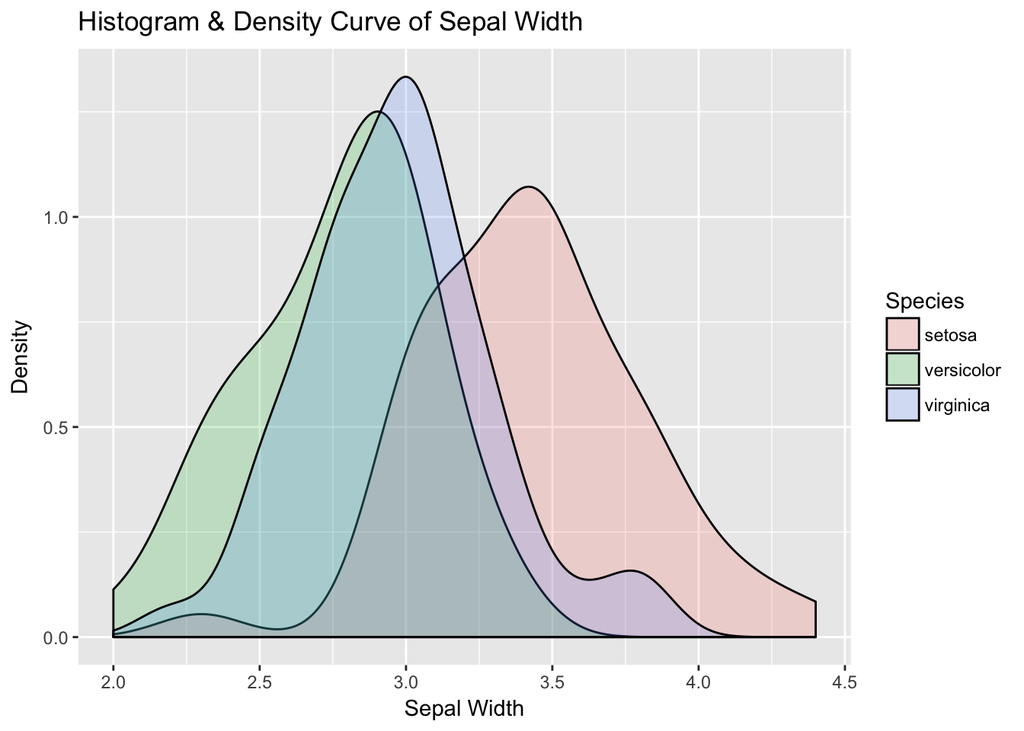

```r
density2 <- ggplot(data=iris, aes(x=Sepal.Width, fill=Species))
density2 + geom_density(stat="density", alpha=I(0.2)) +
  xlab("Sepal Width") +  ylab("Density") + ggtitle("Histogram & Density Curve of Sepal Width")
```